# Practical Machine Learning - Course Project

### Background

This project is prepared as a course project for Coursera Practical Machine Learning Course.

The project introduction is as follow:

Using devices such as Jawbone Up, Nike FuelBand, and Fitbit it is now possible to collect a large amount of data about personal activity relatively inexpensively. These type of devices are part of the quantified self movement - a group of enthusiasts who take measurements about themselves regularly to improve their health, to find patterns in their behavior, or because they are tech geeks. One thing that people regularly do is quantify how much of a particular activity they do, but they rarely quantify how well they do it. In this project, your goal will be to use data from accelerometers on the belt, forearm, arm, and dumbell of 6 participants. They were asked to perform barbell lifts correctly and incorrectly in 5 different ways. More information is available from the website here: http://groupware.les.inf.puc-rio.br/har (see the section on the Weight Lifting Exercise Dataset).

### Data

The training data for this project are available here:

https://d396qusza40orc.cloudfront.net/predmachlearn/pml-training.csv

The test data are available here:

https://d396qusza40orc.cloudfront.net/predmachlearn/pml-testing.csv

The data for this project come from this source: http://groupware.les.inf.puc-rio.br/har. If you use the document you create for this class for any purpose please cite them as they have been very generous in allowing their data to be used for this kind of assignment.

### Expected Result

The gaol of the project is as follow:

The goal of your project is to predict the manner in which they did the exercise. This is the “classe” variable in the training set. You may use any of the other variables to predict with. You should create a report describing how you built your model, how you used cross validation, what you think the expected out of sample error is, and why you made the choices you did. You will also use your prediction model to predict 20 different test cases.

1. Your submission should consist of a link to a Github repo with your R markdown and compiled HTML file describing your analysis. Please constrain the text of the writeup to < 2000 words and the number of figures to be less than 5. It will make it easier for the graders if you submit a repo with a gh-pages branch so the HTML page can be viewed online (and you always want to make it easy on graders :-).
2. You should also apply your machine learning algorithm to the 20 test cases available in the test data above. Please submit your predictions in appropriate format to the programming assignment for automated grading. See the programming assignment for additional details.

### Reproducibility

To reproduce the project, please follow the following setps.

```
    1. Create a project folder
    2. Download the dataset from the links provided in the Data section
    3. Transfer all the downloaded data into the cretaed folers
    4. Set the project folder as the working directory using setwd() command
    5. Load the necessary packages in the working directory
    6. Load the data and run the codes as described below
```

### Methodology

Since the project problem is a multi-class classification problem, 1. we will use random forest algrithm for training and predict the test data. If the result is not satisfactory we will use other alternative algrithm. 2. We will use the Corss-validation methods using 5 Folds.

### Loading Packages

Load the necessary packages and set seed.

```r
library(caret)
library(randomForest)
set.seed(1234)
```

### Getting the Data

After the training and testing data are transferred into the prodject folder, the data could be loaded into the global environment as follow:

```r
training <- read.csv("pml-training.csv",header=TRUE,na.strings=c("NA",""))
testing <- read.csv("pml-testing.csv",header=TRUE,na.strings=c("NA",""))
```

### Checking, Cleaning and Removing Unnecessary Variables

Check the rows and columns of training set.

```r
dim(training)
```

```
## [1] 19622   160
```

```r
dim(testing)
```

```
## [1]  20 160
```

Check the column names.

```r
head(names(training),10)
```

```
##  [1] "X"                    "user_name"            "raw_timestamp_part_1"
##  [4] "raw_timestamp_part_2" "cvtd_timestamp"       "new_window"
##  [7] "num_window"           "roll_belt"            "pitch_belt"
## [10] "yaw_belt"
```

```r
str(training[1:10])
```

```
## 'data.frame':    19622 obs. of  10 variables:
##  $ X                   : int  1 2 3 4 5 6 7 8 9 10 ...
##  $ user_name           : Factor w/ 6 levels "adelmo","carlitos",..: 2 2 2 2 2 2 2 2 2 2 ...
##  $ raw_timestamp_part_1: int  1323084231 1323084231 1323084231 1323084232 1323084232 1323084232 1323084232 1323084232 1323084232 1323084232 ...
##  $ raw_timestamp_part_2: int  788290 808298 820366 120339 196328 304277 368296 440390 484323 484434 ...
##  $ cvtd_timestamp      : Factor w/ 20 levels "02/12/2011 13:32",..: 9 9 9 9 9 9 9 9 9 9 ...
##  $ new_window          : Factor w/ 2 levels "no","yes": 1 1 1 1 1 1 1 1 1 1 ...
##  $ num_window          : int  11 11 11 12 12 12 12 12 12 12 ...
##  $ roll_belt           : num  1.41 1.41 1.42 1.48 1.48 1.45 1.42 1.42 1.43 1.45 ...
##  $ pitch_belt          : num  8.07 8.07 8.07 8.05 8.07 8.06 8.09 8.13 8.16 8.17 ...
##  $ yaw_belt            : num  -94.4 -94.4 -94.4 -94.4 -94.4 -94.4 -94.4 -94.4 -94.4 -94.4 ...
```

Remove the uncecessary variables from the training data set.

```r
trainClRM <- c("X","user_name","raw_timestamp_part_1","raw_timestamp_part_2","cvtd_timestamp","num_window")
training <- training[,!names(training) %in% trainClRM]
```

### Preprocessing the **training** data.

Check the near-zero variace variables and remove from the training set.

```r
nzv <- nearZeroVar(training,saveMetrics=TRUE)
nzv[nzv$nzv, ][1:10, ]
```

```
##                    freqRatio percentUnique zeroVar  nzv
## new_window             47.33      0.010193   FALSE TRUE
## kurtosis_yaw_belt       0.00      0.005096    TRUE TRUE
## skewness_yaw_belt       0.00      0.005096    TRUE TRUE
## amplitude_yaw_belt     32.00      0.015289   FALSE TRUE
## avg_roll_arm           77.00      1.681786   FALSE TRUE
## stddev_roll_arm        77.00      1.681786   FALSE TRUE
## var_roll_arm           38.50      1.656304   FALSE TRUE
## avg_pitch_arm          77.00      1.681786   FALSE TRUE
## stddev_pitch_arm       77.00      1.681786   FALSE TRUE
## var_pitch_arm          77.00      1.681786   FALSE TRUE
```

```r
training <- training[,!nzv$nzv]
dim(training)
```

```
## [1] 19622   111
```

Create a checking missing value utility function and use it to remove any variable which has missing value more than 90% of the data set.

```r
NARemove <- function(data,cutoff){
        NACount <- sapply(training,function (data) sum(is.na(data)))
        NAProportion <- NACount/nrow(training)
        RemovedNA <- NAProportion[NAProportion <= cutoff]
        return (data[,names(RemovedNA)])
}
training <- NARemove(training,0.90)
str(training[1:10])
```

```
## 'data.frame':    19622 obs. of  10 variables:
##  $ roll_belt       : num  1.41 1.41 1.42 1.48 1.48 1.45 1.42 1.42 1.43 1.45 ...
##  $ pitch_belt      : num  8.07 8.07 8.07 8.05 8.07 8.06 8.09 8.13 8.16 8.17 ...
##  $ yaw_belt        : num  -94.4 -94.4 -94.4 -94.4 -94.4 -94.4 -94.4 -94.4 -94.4 -94.4 ...
##  $ total_accel_belt: int  3 3 3 3 3 3 3 3 3 3 ...
##  $ gyros_belt_x    : num  0 0.02 0 0.02 0.02 0.02 0.02 0.02 0.02 0.03 ...
##  $ gyros_belt_y    : num  0 0 0 0 0.02 0 0 0 0 0 ...
##  $ gyros_belt_z    : num  -0.02 -0.02 -0.02 -0.03 -0.02 -0.02 -0.02 -0.02 -0.02 0 ...
##  $ accel_belt_x    : int  -21 -22 -20 -22 -21 -21 -22 -22 -20 -21 ...
##  $ accel_belt_y    : int  4 4 5 3 2 4 3 4 2 4 ...
##  $ accel_belt_z    : int  22 22 23 21 24 21 21 21 24 22 ...
```

Check the number of the NA value for each variables.

```r
NACount <- sapply(training,function (training) sum(is.na(training)))
NACount
```

```
##            roll_belt           pitch_belt             yaw_belt
##                    0                    0                    0
##     total_accel_belt         gyros_belt_x         gyros_belt_y
##                    0                    0                    0
##         gyros_belt_z         accel_belt_x         accel_belt_y
##                    0                    0                    0
##         accel_belt_z        magnet_belt_x        magnet_belt_y
##                    0                    0                    0
##        magnet_belt_z             roll_arm            pitch_arm
##                    0                    0                    0
##              yaw_arm      total_accel_arm          gyros_arm_x
##                    0                    0                    0
##          gyros_arm_y          gyros_arm_z          accel_arm_x
##                    0                    0                    0
##          accel_arm_y          accel_arm_z         magnet_arm_x
##                    0                    0                    0
##         magnet_arm_y         magnet_arm_z        roll_dumbbell
##                    0                    0                    0
##       pitch_dumbbell         yaw_dumbbell total_accel_dumbbell
##                    0                    0                    0
##     gyros_dumbbell_x     gyros_dumbbell_y     gyros_dumbbell_z
##                    0                    0                    0
##     accel_dumbbell_x     accel_dumbbell_y     accel_dumbbell_z
##                    0                    0                    0
##    magnet_dumbbell_x    magnet_dumbbell_y    magnet_dumbbell_z
##                    0                    0                    0
##         roll_forearm        pitch_forearm          yaw_forearm
##                    0                    0                    0
##  total_accel_forearm      gyros_forearm_x      gyros_forearm_y
##                    0                    0                    0
##      gyros_forearm_z      accel_forearm_x      accel_forearm_y
##                    0                    0                    0
##      accel_forearm_z     magnet_forearm_x     magnet_forearm_y
##                    0                    0                    0
##     magnet_forearm_z               classe
##                    0                    0
```

Since there is no variable with NA values, we do not need to impute missing values.

Check the target variable if the classes are imblanced.

```r
round(table(training$classe)/nrow(training)*100,2)
```

```
##
##     A     B     C     D     E
## 28.44 19.35 17.44 16.39 18.38
```

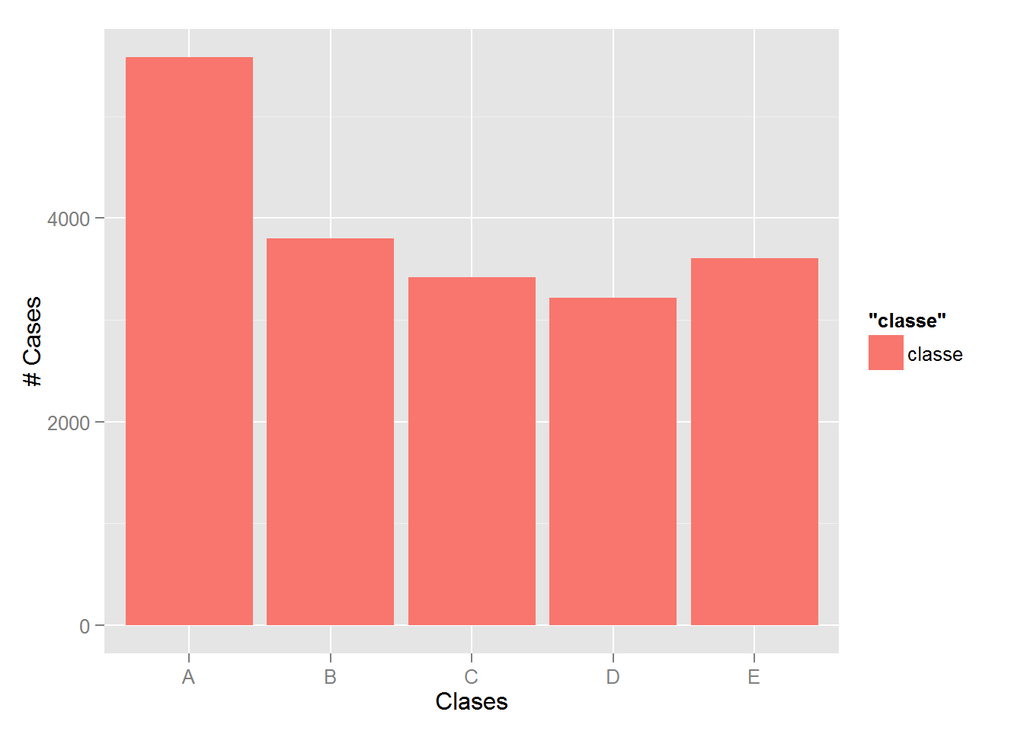

```r
qplot(classe,data=training,,fill="classe",geom="bar",ylab="# Cases",xlab="Clases")
```

The multi-class target variable is fairly balanced, hence no action to be taken such as weighting.

Check the number of rows and columns after cleaning the data set.

```r
dim(training)
```

```
## [1] 19622    53
```

There are now 52 predictors and 1 target variables.

### Data Partition

Split the training data into two: (1) a training data set and (2) validating data set

```r
inTrain <- createDataPartition(training$classe,p=0.60,list=FALSE)
training <- training[inTrain,]
validating <- training[-inTrain,]
```

### Modelling Using Random Forest

Since the project problem is a multi-class classification problem, we will use random forest for modelling and look at the result. If the result is unsatisfactory, we will use other alternative methods.

Set the training control parameters. 1. Method: k-fold cross validation 2. Number of Folds: 5

```r
set.seed(1234)
trControl <- trainControl(method="cv",
                          number=5)
```

Train the data using the control parameters.

```r
rfFit <- train(classe ~.,data=training,
               method="rf",
               importance=TRUE,
               trControl=trControl)
```

Check the result.

```r
rfFit
```

```
## Random Forest
##
## 11776 samples
##    52 predictor
##     5 classes: 'A', 'B', 'C', 'D', 'E'
##
## No pre-processing
## Resampling: Cross-Validated (5 fold)
##
## Summary of sample sizes: 9420, 9420, 9420, 9422, 9422
##
## Resampling results across tuning parameters:
##
##   mtry  Accuracy  Kappa   Accuracy SD  Kappa SD
##    2    0.9883    0.9852  0.002137     0.002704
##   27    0.9894    0.9866  0.002479     0.003136
##   52    0.9812    0.9763  0.004688     0.005928
##
## Accuracy was used to select the optimal model using  the largest value.
## The final value used for the model was mtry = 27.
```

### Error of Estimate

Since we are using the random forest, the error is estimated internally during the run. Hence we will look at the OOB as an out of sample error.

```r
rfFit$resample
```

```
##   Accuracy  Kappa Resample
## 1   0.9898 0.9871    Fold1
## 2   0.9890 0.9860    Fold3
## 3   0.9924 0.9903    Fold2
## 4   0.9902 0.9876    Fold5
## 5   0.9856 0.9817    Fold4
```

```r
rfFit$result
```

```
##   mtry Accuracy  Kappa AccuracySD  KappaSD
## 1    2   0.9883 0.9852   0.002137 0.002704
## 2   27   0.9894 0.9866   0.002479 0.003136
## 3   52   0.9812 0.9763   0.004688 0.005928
```

Since the accurary result is more than 0.98, we estimate the OBB is less than 1%.

```r
rfFit$finalModel
```

```
##
## Call:
##  randomForest(x = x, y = y, mtry = param$mtry, importance = TRUE)
##                Type of random forest: classification
##                      Number of trees: 500
## No. of variables tried at each split: 27
##
##         OOB estimate of  error rate: 0.93%
## Confusion matrix:
##      A    B    C    D    E class.error
## A 3343    4    0    0    1    0.001493
## B   23 2249    6    1    0    0.013164
## C    0   20 2026    8    0    0.013632
## D    0    1   28 1899    2    0.016062
## E    0    1    6    8 2150    0.006928
```

### Model Validation

Validate the result using the validation set.

```r
pred <- predict(rfFit,newdata=validating)
confusionMatrix(pred,validating$classe)
```

```
## Confusion Matrix and Statistics
##
##           Reference
## Prediction    A    B    C    D    E
##          A 1346    0    0    0    0
##          B    0  904    0    0    0
##          C    0    0  814    0    0
##          D    0    0    0  774    0
##          E    0    0    0    0  854
##
## Overall Statistics
##
##                Accuracy : 1
##                  95% CI : (0.999, 1)
##     No Information Rate : 0.287
##     P-Value [Acc > NIR] : <2e-16
##
##                   Kappa : 1
##  Mcnemar's Test P-Value : NA
##
## Statistics by Class:
##
##                      Class: A Class: B Class: C Class: D Class: E
## Sensitivity             1.000    1.000    1.000    1.000    1.000
## Specificity             1.000    1.000    1.000    1.000    1.000
## Pos Pred Value          1.000    1.000    1.000    1.000    1.000
## Neg Pred Value          1.000    1.000    1.000    1.000    1.000
## Prevalence              0.287    0.193    0.173    0.165    0.182
## Detection Rate          0.287    0.193    0.173    0.165    0.182
## Detection Prevalence    0.287    0.193    0.173    0.165    0.182
## Balanced Accuracy       1.000    1.000    1.000    1.000    1.000
```

The random forest algorithm products a good result with a high accurary at >0.9. Hence, we will not try another algorithm but will use this to predict for the testing data set.

### Applying the model to the Model test

Prepare the testing data set. 1. Select variables used in the training set. 2. Make the class of testing data set same as the training set

```r
#Select variables used in training set
testing <- testing[,names(testing) %in% names(training)]
#Get the class of the training set.
colClass <- sapply(training,function(x) class(x))
#Making the class of testing set same as training set.
for(i in 1:(ncol(training)-1)){
        class(testing[,names(colClass[i])]) <- colClass[[i]]
}
```

After the testing data set is cleaned and prepared, predict the testing data using the training fit.

```r
prediction <- predict(rfFit,newdata=testing)
prediction
```

```
##  [1] B A B A A E D B A A B C B A E E A B B B
## Levels: A B C D E
```

### Generating files for Submission.

Use the following code chunk to produce the result for submission.

```r
pml_write_files = function(x){
        n = length(x)
        for(i in 1:n){
                filename = paste0("problem_id_",i,".txt")
                write.table(x[i],file=filename,quote=FALSE,row.names=FALSE,col.names=FALSE)
        }
}

pml_write_files(prediction)
```

As expected, all the submitted results are corret.